# Blount

Topics that will be discussed in this summary report for Blount County are

- Demographic Characteristics
  - Population growth from 1970 to 2020;
  - population density
  - sex, race, and age
  - educational level of the adult population
  - housing characteristics in terms of age of the housing stock and type of tenure
- Economic Characteristics
  - family income, household income, per capita income,
  - poverty status of families;
  - employment classification according to industry;
  - labor force by place of work and commuting patterns;

For more details on the data used, please see the Data Description tab.

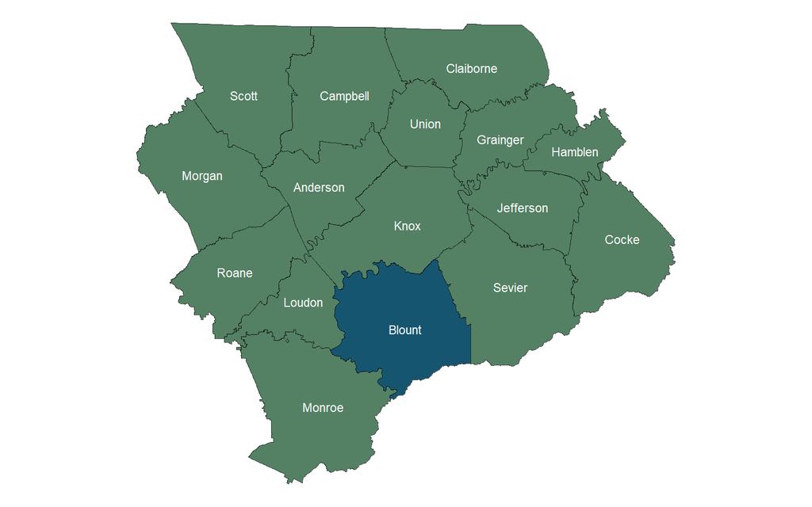

**Population and Growth**

| Place | 1970 | 1980 | 1990 | 2000 | 2010 | 2020 | Change 1970-1980 | Change 1980-1990 | Change 1990-2000 | Change 2000-2010 | Change 2010-2020 |
| --- | --- | --- | --- | --- | --- | --- | --- | --- | --- | --- | --- |
| Blount County | 63744 | 77770 | 85969 | 105823 | 123010 | 135280 | 14026 | 8199 | 19854 | 17187 | 12270 |
| Alcoa | 7739 | 6870 | 6400 | 7734 | 8449 | 10978 | -869 | -470 | 1334 | 715 | 2529 |
| Friendsville |  | 694 | 792 | 890 | 913 | 896 |  | 98 | 98 | 23 | -17 |
| Louisville |  |  |  | 2001 | 2439 | 4384 |  |  |  | 438 | 1945 |
| Maryville | 13808 | 17480 | 19208 | 23120 | 27465 | 31907 | 3672 | 1728 | 3912 | 4345 | 4442 |
| Rockford |  | 567 | 646 | 798 | 856 | 822 |  | 79 | 152 | 58 | -34 |
| Townsend |  | 351 | 329 | 244 | 448 | 550 |  | -22 | -85 | 204 | 102 |

[interactive chart not shown]

IPUMS NHGIS, University of Minnesota, www.nhgis.org

**Population Density**

| Place | Area | Population Density |
| --- | --- | --- |
| Blount County | 566.5569465138609 | 238.7756444121021 |
| Alcoa | 15.91222189773494 | 689.909936560317 |
| Friendsville | 2.83800768844744 | 315.7144371550895 |
| Louisville | 17.05260949986836 | 257.0867526189374 |
| Maryville | 17.24982862768816 | 1849.699535494818 |
| Rockford | 3.202251147519807 | 256.6944196855551 |
| Townsend | 1.992400323080862 | 276.0489413841949 |

[interactive chart not shown]

source: U. S. Census Bureau *Decennial Census: Redistricting Data (PL 94-171)*, 2020, accessed June 2, 2026, http://api.census.gov/data/2020/dec/pl.

**Population Descriptions**

| Place | Year | Race Category | Number of People | Percentage of People |
| --- | --- | --- | --- | --- |
| Blount County | 2020 | Black | 3628 | 0.0196302288209418 |
| Blount County | 2020 | Other | 12285 | 0.06647115795624861 |
| Blount County | 2020 | White | 119367 | 0.6458659106034618 |
| Alcoa | 2020 | Black | 1279 | 0.006920359057878874 |
| Alcoa | 2020 | Other | 1344 | 0.007272058306324635 |
| Alcoa | 2020 | White | 8355 | 0.04520688031945113 |
| Friendsville | 2020 | Black | 1 | 5.410757668396306e-06 |
| Friendsville | 2020 | Other | 63 | 0.0003408777331089673 |
| Friendsville | 2020 | White | 832 | 0.004501750380105726 |
| Louisville | 2020 | Black | 80 | 0.0004328606134717045 |

[output cut: 11 more lines]

| Place | Sex | Age Range | Year | Number of People | Percentage of People |
| --- | --- | --- | --- | --- | --- |
| Blount County | Female | 10 to 14 years | 2020 | 3569 | 0.02012620466810653 |
| Blount County | Female | 15 to 19 years | 2020 | 3986 | 0.02247773936875109 |
| Blount County | Female | 20 to 24 years | 2020 | 3650 | 0.02058297759556987 |
| Blount County | Female | 25 to 29 years | 2020 | 3939 | 0.02221269828738348 |
| Blount County | Female | 30 to 34 years | 2020 | 3730 | 0.02103411135108921 |
| Blount County | Female | 35 to 39 years | 2020 | 4123 | 0.02325030592507796 |
| Blount County | Female | 40 to 44 years | 2020 | 3634 | 0.020492750844466 |
| Blount County | Female | 45 to 49 years | 2020 | 4629 | 0.02610372692873779 |
| Blount County | Female | 5 to 9 years | 2020 | 3782 | 0.02132734829217678 |
| Blount County | Female | 50 to 54 years | 2020 | 4832 | 0.02724847883336811 |

[output cut: 242 more lines]

[interactive chart not shown]

source: U. S. Census Bureau *Decennial Census: Redistricting Data (PL 94-171)*, 2020, accessed June 2, 2026, http://api.census.gov/data/2020/dec/pl.

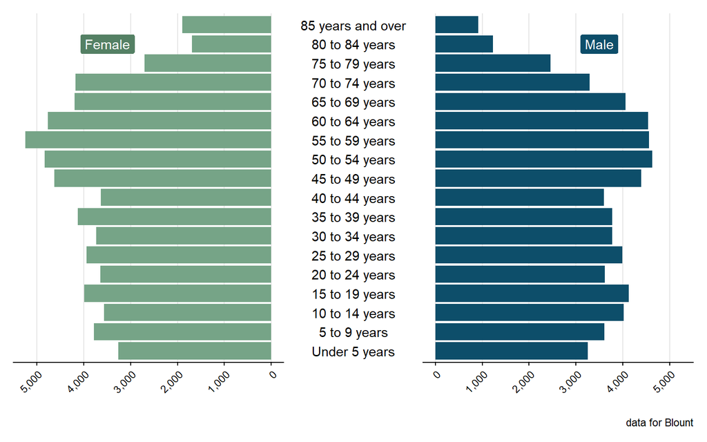

source: U. S. Census Bureau *American Community Survey 5-Year Estimates: Comparison Profiles 5-Year*, 2020, accessed June 2, 2026, http://api.census.gov/data/2020/acs/acs5.

**Education**

| Place | Level of Education | Year | Number of People | Percentage of People |
| --- | --- | --- | --- | --- |
| Blount County | 9th to 12th Grade, No Diploma | 2010 | 6279 | 0.05613467315119439 |
| Blount County | Associate's degree | 2010 | 5349 | 0.04782041195823201 |
| Blount County | Bachelor's degree | 2010 | 11180 | 0.09994993563152625 |
| Blount County | Graduate or Professional Degree | 2010 | 6165 | 0.05511550565012158 |
| Blount County | Less Than 9th Grade | 2010 | 4675 | 0.04179480760978401 |
| Blount County | Some College, No Degree | 2010 | 19222 | 0.1718459447861536 |
| Blount County | Total | 2010 | 84160 | 0.752395937634101 |
| Blount County | 9th to 12th Grade, No Diploma | 2020 | 5004 | 0.03975025022639531 |
| Blount County | Associate's degree | 2020 | 7432 | 0.0590375419029916 |
| Blount County | Bachelor's degree | 2020 | 14728 | 0.1169947412738509 |

[output cut: 88 more lines]

[interactive chart not shown]

source: U. S. Census Bureau *American Community Survey 5-Year Estimates: Comparison Profiles 5-Year*, 2020, accessed June 2, 2026, http://api.census.gov/data/2020/acs/acs5.

**Housing Units by Year of Construction**

| Place | Year | 1939 or earlier | 1940-1959 | 1960-1979 | 1980 to 1989 | 1990 to 1999 | 2000 to 2004 | 2005 or later | 2000 to 2009 | 2010 or later | Total |
| --- | --- | --- | --- | --- | --- | --- | --- | --- | --- | --- | --- |
| Blount County | 2010 | 3426 | 7165 | 13888 | 8783 | 11983 | 6406 | 2601 |  |  | 54252 |
| Blount County | 2020 | 3349 | 7605 | 12931 | 7679 | 11595 |  |  | 11060 | 4101 | 58320 |
| Alcoa | 2010 | 666 | 1099 | 853 | 605 | 334 | 273 | 75 |  |  | 3905 |
| Friendsville | 2010 | 62 | 62 | 104 | 57 | 59 | 28 | 4 |  |  | 376 |
| Louisville | 2010 | 75 | 79 | 449 | 110 | 238 | 214 | 35 |  |  | 1200 |
| Maryville | 2010 | 928 | 2254 | 3142 | 1689 | 1958 | 1062 | 514 |  |  | 11547 |
| Rockford | 2010 | 34 | 73 | 138 | 147 | 45 | 12 | 0 |  |  | 449 |
| Townsend | 2010 | 83 | 45 | 128 | 106 | 148 | 2 | 7 |  |  | 519 |
| Alcoa | 2020 | 564 | 1074 | 920 | 489 | 573 |  |  | 518 | 254 | 4392 |
| Friendsville | 2020 | 77 | 82 | 118 | 47 | 67 |  |  | 39 | 11 | 441 |

[output cut: 4 more lines]

[interactive chart not shown]

source: U. S. Census Bureau *Decennial Census: Redistricting Data (PL 94-171)*, 2020, accessed June 2, 2026, http://api.census.gov/data/2020/dec/pl.

**Housing Units by Type of Tenure**

| Place | Year | Own | Rent | Total |
| --- | --- | --- | --- | --- |
| Blount County | 2010 | 36642 | 11509 | 48151 |
| Blount County | 2020 | 39279 | 11995 | 51274 |
| Alcoa | 2010 | 2213 | 1210 | 3423 |
| Friendsville | 2010 | 299 | 69 | 368 |
| Louisville | 2010 | 882 | 160 | 1042 |
| Maryville | 2010 | 7128 | 3522 | 10650 |
| Rockford | 2010 | 273 | 93 | 366 |
| Townsend | 2010 | 295 | 63 | 358 |
| Alcoa | 2020 | 2504 | 1411 | 3915 |
| Friendsville | 2020 | 277 | 98 | 375 |

[output cut: 4 more lines]

[interactive chart not shown]

source: U. S. Census Bureau *Decennial Census: Redistricting Data (PL 94-171)*, 2020, accessed June 2, 2026, http://api.census.gov/data/2020/dec/pl.

**Income Comparison**

| Place | Year | Median Family Income | Median Household Income | Per Capita Income |
| --- | --- | --- | --- | --- |
| Blount County | 2020 | 73803 | 60301 | 31231 |
| Alcoa | 2020 | 63273 | 48351 | 26552 |
| Friendsville | 2020 | 61500 | 51250 | 24726 |
| Louisville | 2020 | 86250 | 73385 | 45251 |
| Maryville | 2020 | 85359 | 66038 | 32075 |
| Rockford | 2020 | 69886 | 64583 | 37934 |
| Townsend | 2020 | 72409 | 70701 | 32475 |

[interactive chart not shown]

**Povery Status**

| Place | Year | Above Poverty | Below Poverty |
| --- | --- | --- | --- |
| Blount County | 2020 | 33129 | 2423 |
| Alcoa | 2020 | 2481 | 106 |
| Friendsville | 2020 | 262 | 14 |
| Louisville | 2020 | 1231 | 82 |
| Maryville | 2020 | 6739 | 506 |
| Rockford | 2020 | 224 | 25 |
| Townsend | 2020 | 188 | 17 |

[interactive chart not shown]

source: U. S. Census Bureau *American Community Survey 5-Year Estimates: Comparison Profiles 5-Year*, 2020, accessed June 2, 2026, http://api.census.gov/data/2020/acs/acs5.

**Poverty Status by Family Type**

| Place | Poverty Status | Family Type | Number of Families | Year | Percentage of Families |
| --- | --- | --- | --- | --- | --- |
| Blount County | Above Poverty | All Families | 33129 | 2020 | 0.698526155987096 |
| Blount County | Above Poverty | Female Householder | 4126 | 2020 | 0.08699685832964345 |
| Blount County | Above Poverty | Female Householder with related children | 1923 | 2020 | 0.04054652413182364 |
| Blount County | Below Poverty | All Families | 2423 | 2020 | 0.05108904210681679 |
| Blount County | Below Poverty | Female Householder | 1077 | 2020 | 0.02270858371813524 |
| Blount County | Below Poverty | Female Householder with related children | 756 | 2020 | 0.01594028717818964 |
| Alcoa | Above Poverty | All Families | 2481 | 2020 | 0.05231197419191599 |
| Alcoa | Above Poverty | Female Householder | 534 | 2020 | 0.01125940919729268 |
| Alcoa | Above Poverty | Female Householder with related children | 241 | 2020 | 0.005081493663946697 |
| Alcoa | Below Poverty | All Families | 106 | 2020 | 0.002235013810698547 |

[output cut: 32 more lines]

[interactive chart not shown]

source: U. S. Census Bureau *American Community Survey 5-Year Estimates: Comparison Profiles 5-Year*, 2020, accessed June 2, 2026, http://api.census.gov/data/2020/acs/acs5.

**Employment by Industry**

| Place | Industry | Year | Number of Jobs | Percentage of Jobs |
| --- | --- | --- | --- | --- |
| Alcoa | Arts, Entertainment, And Recreation, And Accommodation And Food Services | 2010 | 302 | 0.08131394722670975 |
| Alcoa | Arts, Entertainment, And Recreation, And Accommodation And Food Services | 2020 | 731 | 0.01183249971673222 |
| Alcoa | Educational Services, And Health Care And Social Assistance | 2010 | 691 | 0.1860527732902531 |
| Alcoa | Educational Services, And Health Care And Social Assistance | 2020 | 1042 | 0.01686657278363198 |
| Alcoa | Manufacturing | 2010 | 442 | 0.11900915455035 |
| Alcoa | Manufacturing | 2020 | 814 | 0.01317599831658007 |
| Alcoa | Other Industries | 2010 | 1984 | 0.5341949380721593 |
| Alcoa | Other Industries | 2020 | 1354 | 0.02191683258065038 |
| Alcoa | Professional, Scientific, And Management, And Administrative, And Waste Management Services | 2020 | 372 | 0.07693898655635988 |
| Alcoa | Retail Trade | 2010 | 295 | 0.07942918686052773 |

[output cut: 67 more lines]

[interactive chart not shown]

source: U. S. Census Bureau *American Community Survey 5-Year Estimates: Comparison Profiles 5-Year*, 2020, accessed June 2, 2026, http://api.census.gov/data/2020/acs/acs5.

**Employment by Industry (Historical)**

| Place | Year | Industry | Number of Jobs | Percentage of Jobs |
| --- | --- | --- | --- | --- |
| Alcoa | 2010 | Agriculture, Forestry, Fishing And Hunting, And Mining | 8 | 0.0001070019394101518 |
| Alcoa | 2010 | Construction | 319 | 0.004266702333979804 |
| Alcoa | 2010 | Manufacturing | 442 | 0.005911857152410887 |
| Alcoa | 2010 | Other | 204 | 0.002728549454958871 |
| Alcoa | 2010 | Professional Services | 1636 | 0.02188189660937604 |
| Alcoa | 2010 | Public Administration | 170 | 0.002273791212465726 |
| Alcoa | 2010 | Trade, Finance, Insurance &amp; Real Estate | 935 | 0.01250585166856149 |
| Alcoa | 2020 | Agriculture, Forestry, Fishing And Hunting, And Mining | 10 | 0.0001203166734846115 |
| Alcoa | 2020 | Construction | 442 | 0.005317996968019829 |
| Alcoa | 2020 | Manufacturing | 814 | 0.009793777221647376 |

[output cut: 88 more lines]

**Labor Force by Place of Work**

| Place | Year | Work Out Of State | Work Out of County of Residence | Work in County of Residence |
| --- | --- | --- | --- | --- |
| Blount County | 2020 | 562 | 21559 | 39093 |
| Alcoa | 2020 | 66 | 1726 | 3033 |
| Friendsville | 2020 | 6 | 139 | 358 |
| Louisville | 2020 | 94 | 926 | 1090 |
| Maryville | 2020 | 80 | 4233 | 8902 |
| Rockford | 2020 | 2 | 135 | 262 |
| Townsend | 2020 | 0 | 23 | 152 |

[interactive chart not shown]

source: U. S. Census Bureau *American Community Survey 5-Year Estimates: Comparison Profiles 5-Year*, 2020, accessed June 2, 2026, http://api.census.gov/data/2020/acs/acs5.

**Commuting Patterns**

| Home County | Year | Number of Jobs | Percentage of Jobs |
| --- | --- | --- | --- |
| Blount | 2020 | 24251 | 0.2692341852254813 |
| Blount | 2010 | 21244 | 0.2358505229033905 |
| Knox | 2020 | 11626 | 0.1290716521970824 |
| Knox | 2010 | 8179 | 0.0908031174367742 |
| Loudon | 2020 | 1840 | 0.02042764837800031 |
| Sevier | 2020 | 1735 | 0.0192619401825166 |
| Sevier | 2010 | 1243 | 0.01379976463796434 |
| Loudon | 2010 | 1233 | 0.01368874480982303 |
| Anderson | 2020 | 984 | 0.01092435108910451 |
| Anderson | 2010 | 704 | 0.007815795901147945 |

[output cut: 3 more lines]

| Work County | Year | Number of Jobs | Percentage of Jobs |
| --- | --- | --- | --- |
| Blount | 2020 | 24251 | 0.2692341852254813 |
| Blount | 2010 | 21244 | 0.2358505229033905 |
| Knox | 2020 | 17738 | 0.1969269711570487 |
| Knox | 2010 | 15928 | 0.1768323822634723 |
| Sevier | 2020 | 2001 | 0.02221506761107534 |
| Sevier | 2010 | 1476 | 0.01638652663365677 |
| Loudon | 2020 | 1325 | 0.01471012722872305 |
| Monroe | 2020 | 1062 | 0.0117903057486067 |
| Loudon | 2010 | 973 | 0.01080222927814908 |
| Monroe | 2010 | 721 | 0.008004529608988165 |

[output cut: 3 more lines]

[interactive chart not shown]

source: U. S. Census Bureau *Tn_od_main_JT00_2020*, LEHD Origin-Destination Employment Statistics, 8.3, 2020, accessed June 2, 2026, https://lehd.ces.census.gov/data/lodes/.

## References

Bureau, U. S. Census. *American Community Survey 5-Year Estimates: Comparison Profiles 5-Year*. 2020. Accessed June 2, 2026. http://api.census.gov/data/2020/acs/acs5.

Bureau, U. S. Census. *Decennial Census: Redistricting Data (PL 94-171)*. 2020. Accessed June 2, 2026. http://api.census.gov/data/2020/dec/pl.

Bureau, U. S. Census. *Tn_od_main_JT00_2020*. LEHD Origin-Destination Employment Statistics, 8.3. 2020. Accessed June 2, 2026. https://lehd.ces.census.gov/data/lodes/.